# Análisis de datos para predictor de eventos cardíacos

Juan Cruz De Lorenzo, Agustin Augurusa, Florencia Froschauer

### Introducción

Hay muchos factores que influyen a la hora de decidir si un paciente puede llegar a sufrir algún tipo de problema coronario, y más importante, determinar si la va a padecer en un periodo cercano de tiempo. Con el objetivo de facilitar la decisión de internar o no internar a un paciente ingresante, se realizó la siguiente investigación, con datos obtenidos de un registro de 1000 pacientes.

### Análisis de datos

In the dataset we find 20 variables that represent the questions that a patient is asked when they enter the guard, to determine which ones are important we investigated the main risk factors for people with cardiac events and their causes.

##### Gender

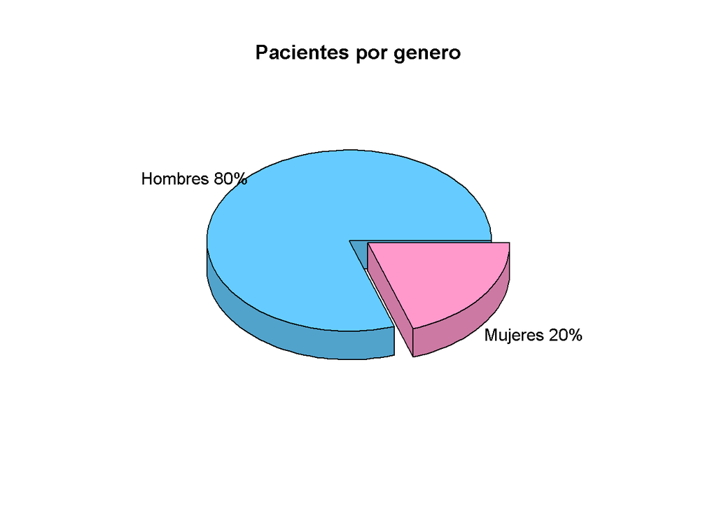

Hicimos este gráfico con el fin de determinar qué género se ve más afectado por problemas coronarios, como se puede ver, el porcentaje de hombres es ampliamente mayor al de mujeres.

##### Age

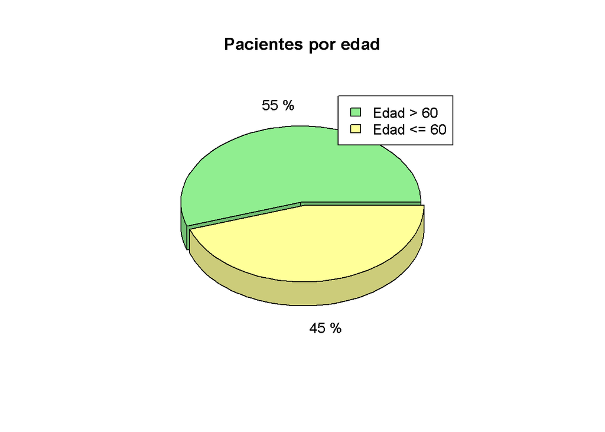

Según un estudio realizado por la Fundación Española del Corazón, “la prevalencia y la incidencia de insuficiencia cardiaca se duplica cada década a partir de los 40-45 años”, a su vez, “la mayor parte de los factores de riesgo cardiovascular continúan siéndolo por encima de los 80 años”. Confirmando esto, en el gráfico se observa que más del cincuenta por ciento de los pacientes con eventos son mayores a 60 años.

#### Presencia de diferentes factores en pacientes con eventos cardíacos

Nos pareció interesante buscar una distinción entre los factores presentados en el dataset, para esto los dividimos entre causantes preexistentes y causas in actu, esto nos permitirá analizar desde otro punto de vista a los pacientes respecto a los distintos factores o síntomas que pueden presentar. Entre los primeros se encontrarían los principales factores de riesgo, como son el tabaquismo, la hipertensión o colesterol. Los segundos representan los síntomas que la mayoría de pacientes presenta al momento de tener problemas coronarios

##### Factores principales

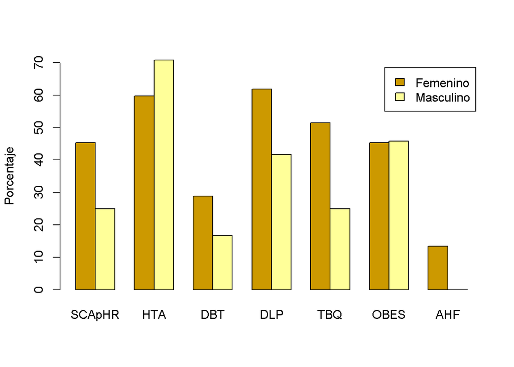

Para un mejor análisis dividimos a los pacientes por género, visualizando en qué proporción están presentes los factores según el género. El factor más presente en los hombres es la hipertensión, mientras que en las mujeres es el colesterol.

##### Factores secundarios

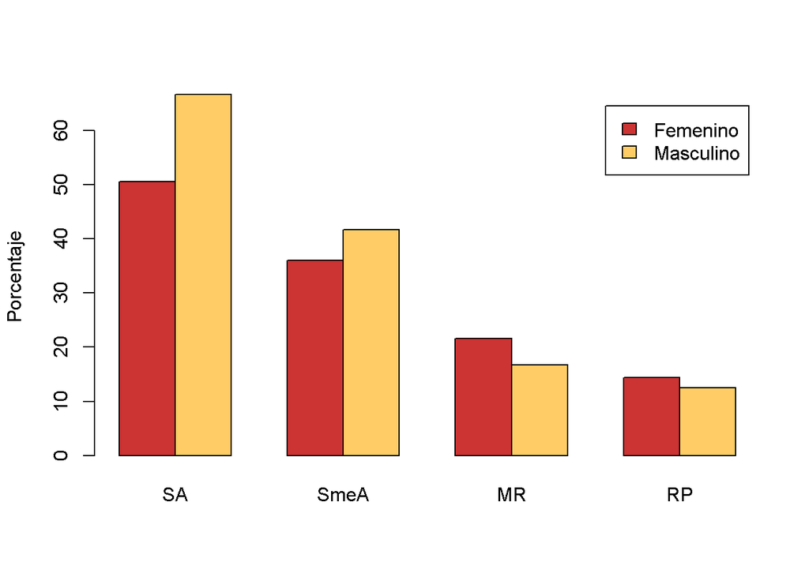

Este gráfico presenta variables que, por lo general, se presentan junto a problemas cardíacos, como pueden ser náuseas, disnea o dolor en el pecho. Nuevamente dividimos a los pacientes por género y se observa que tanto en los hombres como en las mujeres, los síntomas más frecuentes son sudoración, náuseas, mareos y disnea

#### Rango de edad para cada factor de riesgo

##### Hipertensión

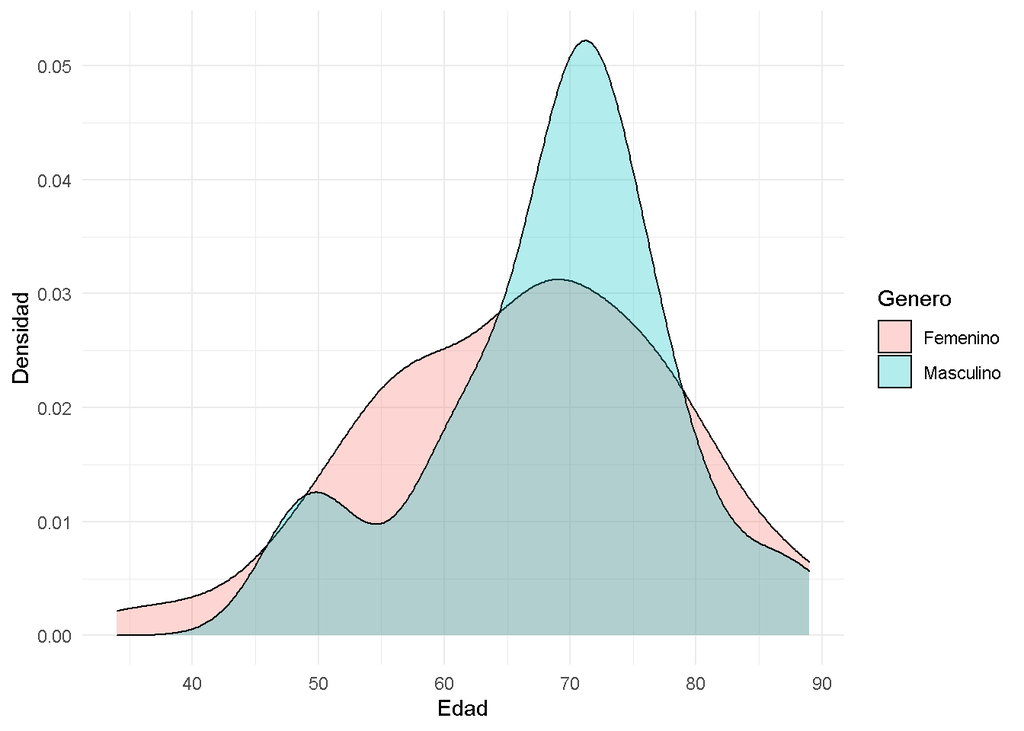

La presión arterial alta es una enfermedad común en la cual la sangre fluye a través de los vasos sanguíneos o arterias a presiones más altas que la normal. En el gráfico se observa una clara diferencia en la presencia de la enfermedad según el género. Los hombres presentan un pico muy alto alrededor de los 70 años, mientras que en las mujeres hay una distribución más uniforme con un pico suave también alrededor de los 70 años.

##### Colesterol

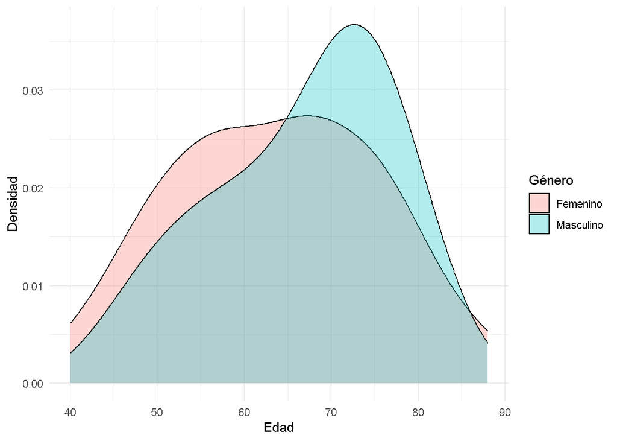

Si hay grandes depósitos de placa (colesterol en sangre combinado con otras sustancias) en las arterias, un trozo de placa puede romperse. Esto puede causar que se forme un coágulo de sangre. Si el coágulo es lo suficientemente grande, puede bloquear un poco o completamente el flujo de sangre en una arteria coronaria. Los niveles de colesterol tienden a aumentar a medida que se envejece. Ambas cosas se ven reflejadas en el gráfico, donde los hombres de edad entre los 70 y 80 años con colesterol presentan algún problema coronario. Las mujeres presentan una meseta entre las edades de 50 a 70 años.

##### Tabaquismo

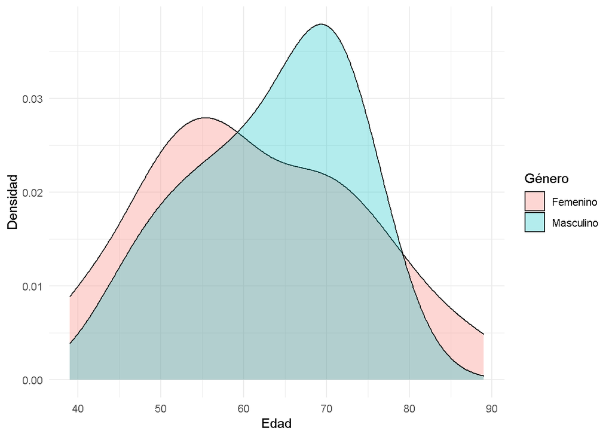

El tabaquismo desemboca en otros problemas de salud como: problemas respiratorios; el daño y engrosamiento de los vasos sanguíneos, lo que causa presión arterial alta; coágulos de sangre y accidente cerebrovascular. Todos factores de riesgo para los problemas coronarios. Las mujeres presentan un pico en el rango de edades entre los 50 y 60 años, los hombres lo presentan en una edad más tardía, alrededor de los 70 años.

##### Obesidad

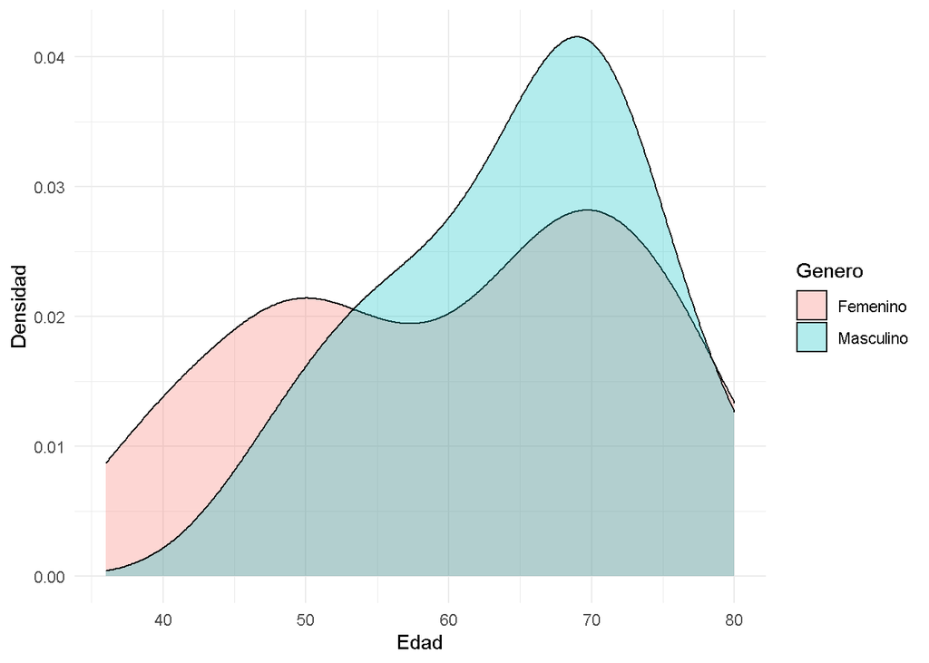

Estudios epidemiológicos han demostrado que la obesidad es un factor de riesgo mayor de enfermedades cardiovasculares, incluidas la enfermedad coronaria, la insuficiencia cardiaca, la fibrilación auricular, las arritmias ventriculares y la muerte súbita. Las mujeres presentan dos suaves picos, el primero en los 50 años y el segundo en los 70 años. En los hombres se observa un único pico más elevado a los 70 años.

##### Diabetes

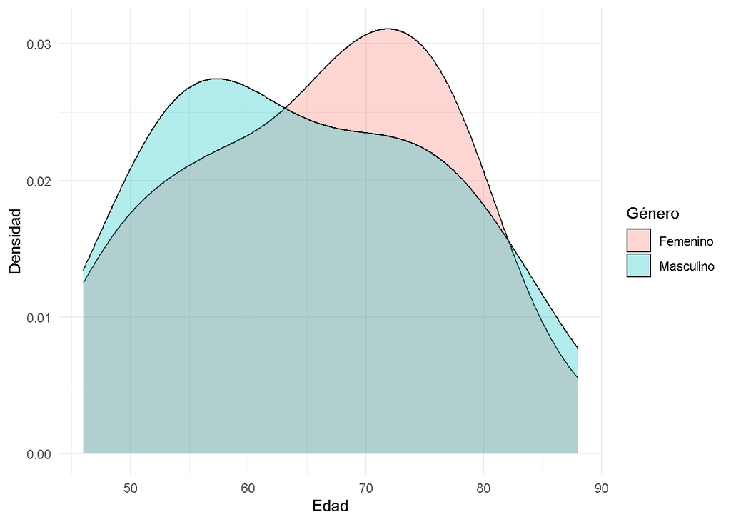

La diabetes es una enfermedad en la que los niveles de glucosa (azúcar) de la sangre están muy altos. Con el tiempo, la diabetes puede causar enfermedades cardíacas. Se encuentra bastante presente tanto en hombres como mujeres, en los primeros con un pico entre los 50 y 60 años, mientras que en las mujeres hay un pico más elevado entre los 70 y 80 años.

Datos obtenidos de la página oficial del National Heart, Lung, and Blood Institute y del artículo Obesity and the Heart de la Revista española de cardiología.

[output not shown]

#### Pacientes con síndrome anginoso

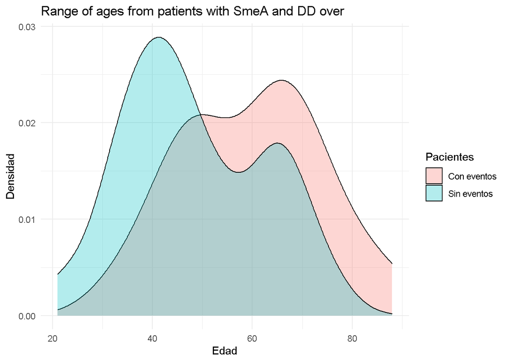

El Consenso de la Sociedad Argentina de Cardiología realizado en 2013, considera como pacientes de alto riesgo aquellos que presentan síntomas anginosos, con “dolor prolongado mayor de 20 minutos de duración presente al ingreso”. Con esto en mente, buscamos los pacientes que cumplian con dichos síntomas y los separamos según si presentaban problemas coronarios o no. En el gráfico se observa un pico en los pacientes sin eventos, lo que indica que estos síntomas presentes en una temprana edad no representarían un riesgo; un segundo pico presente en los pacientes con eventos, señala un mayor riesgo de contraer algún problema coronario en una edad avanzada.

#### Caracteristicas del Dolor

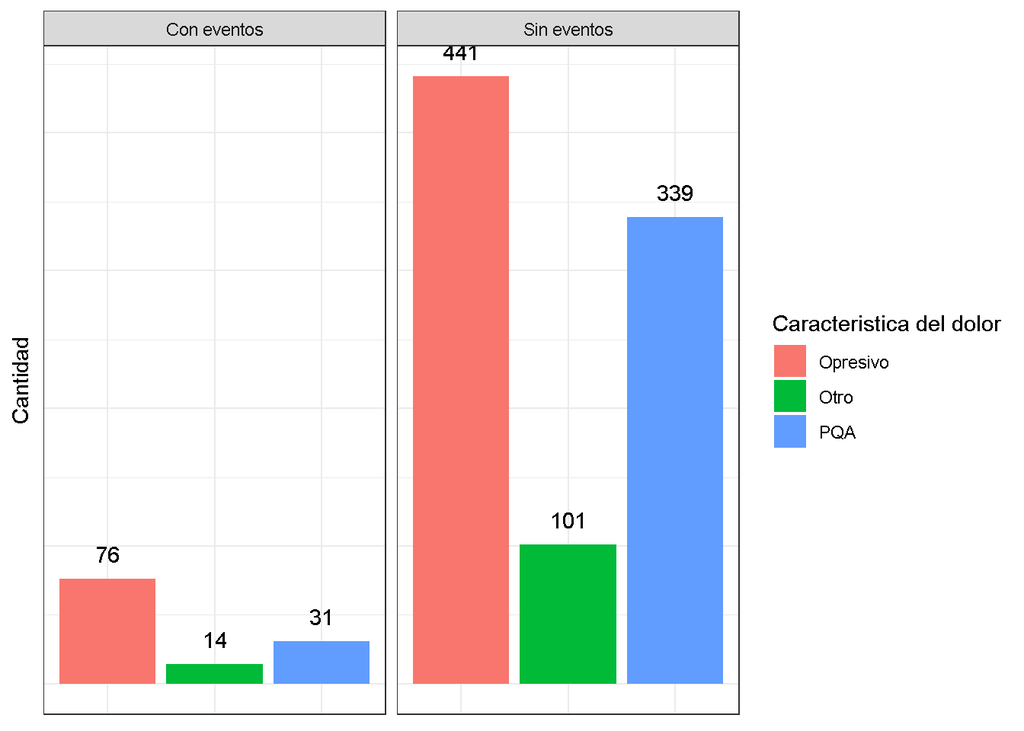